# C06 — Dwie grupy: różnica czasu lub samooceny i tasowanie etykiet

Zarządzanie informacją — ćwiczenie i zadanie Z06 — 2026/27

2026/27

# Początek pracy na ćwiczeniu C06

Otwórz swój projekt kursu w Posit Cloud albo RStudio na własnym komputerze; pakiet kursu `badaniaZI` jest w nim zainstalowany. Dwa polecenia z następnego bloku wpisujesz w konsoli RStudio, czyli w dolnym panelu ze znakiem `>`; w miejsce `TWOJE_ID` wpisz swoje ID, a w miejsce `Imię Nazwisko` — swoje imię i nazwisko. Dokument PDF zawiera dwa polecenia jako tekst instrukcji.

```r
library(badaniaZI)
rozpocznij_zajecia("C06", id_studenta = "TWOJE_ID", student = "Imię Nazwisko")
```

Sprawdź w komunikacie ID oraz imię i nazwisko. Przy pierwszym starcie funkcja tworzy folder `moje-badania` i zapisuje w nim oba dane; pliki pracy zachowują je także po zamknięciu projektu, a imię i nazwisko trafiają do nazwy oddawanego pliku.

Funkcja `rozpocznij_zajecia()` otwiera własny plik `zadanie.Rmd`, zapamiętuje katalog pracy i kopiuje do folderu `moje-badania/materialy` wersję HTML i PDF ćwiczenia oraz rubrykę zadania. Pracuj w otwartym pliku `zadanie.Rmd` do końca zajęć. Najpierw uruchom blok `przygotowanie`, a potem kolejne części LEARN i CHALLENGE. Przy problemie poproś prowadzącego o pomoc; plik pracy i własne ID pozostają bez zmian.

Pierwszy chunk, `przygotowanie`, wczytuje gotowy skrypt `analiza.R`. Skrypt tworzy zbiór S02 po trzech regułach ćwiczenia C02 (usunięcie identycznych duplikatów, kod 99 w pozycjach ankiety jako brak, czas spoza 0–120 minut jako brak) i liczy indeks sześciu pozycji według reguły 5/6 z ćwiczenia C04. Funkcja `porownaj_grupy()` porównuje dwie grupy w jawnej kolejności. Skrypt zawiera też dane repozytorium do części CHALLENGE, demonstracje tasowania, przedziałów i par oraz funkcje wyświetlające tabele i wykresy.

# Czy nowi użytkownicy inaczej oceniają katalog

Ćwiczenie C05 (Niepewność estymaty) porównało średnią całej próby z umownym punktem 3: średnia 3,292, różnica 0,292 punktu, p < 0,001. Biblioteka sprawdza teraz, czy wynik zbiorczy obejmuje różnicę między nowymi i doświadczonymi użytkownikami. Pytanie ma sens organizacyjny: osoba rozpoczynająca korzystanie potrzebuje innego wsparcia niż osoba znająca katalog.

Przyczynę różnicy wyjaśniają cechy grup: zadania, oczekiwania, nawyki i wcześniejsze kontakty z biblioteką. Grupa w S02 jest cechą obserwowaną, więc wynik opisuje związek i różnicę.

Analiza zaczyna od indeksu deklarowanej użyteczności katalogu, a potem przechodzi do czasu wykonania. Ocena i czas to dwa wskaźniki o własnych kierunkach i jednostkach.

Dane są syntetyczne. LEARN przedstawia sposób analizy na indeksie S02. W CHALLENGE wykonujesz analogiczną analizę czasu w repozytorium i piszesz odpowiedzi w tym samym pliku. Projekt indywidualny rozpoczyna się na ćwiczeniu C09 (Warsztat projektu).

## Przebieg spotkania

Przeznacz około 5 minut na odtworzenie pracy, 30 minut na pięć bloków LEARN, 50 minut na pięć zadań CHALLENGE i 5 minut na zapis oraz oddanie. W LEARN uruchamiasz gotowy kod i porównujesz wynik z podaną interpretacją. W CHALLENGE piszesz własne krótkie akapity pod wynikami, poza blokiem R. Gdy odczyt wyniku sprawia trudność, pytasz prowadzącego. Rozwinięcia po części obowiązkowej służą powtórce i pozostają poza oceną.

Celem jest sprawdzenie, czy znak, jednostka, N, statystyka i przedział opowiadają tę samą historię. Ta sama kontrola przydaje się przy czytaniu gotowych raportów i artykułów.

Bloki LEARN kończą się **wzorcem zapisu** — przykładowym zdaniem według standardu APA (*Publication Manual of the American Psychological Association*, 7. wydanie, 2020): symbol statystyczny kursywą, stopnie swobody w nawiasie, przedział w nawiasie kwadratowym, przecinek jako separator dziesiętny. Na ćwiczeniu C06 wzorce dotyczą porównania dwóch grup: opisu, testu Welcha, efektu z przedziałem, bootstrapu i tasowania. Zadania CHALLENGE stosują wzorce do czasu w repozytorium.

# LEARN 1: pytanie, grupy i opis danych

Grupa 1 to doświadczeni, a grupa 2 — nowi. Estymanda i estymata mają postać:

$$\Delta=\mu_{\mathrm{nowi}}-\mu_{\mathrm{doświadczeni}},
\qquad
\widehat\Delta=\bar{x}_{\mathrm{nowi}}-\bar{x}_{\mathrm{doświadczeni}}.$$

Wartość ujemna oznacza niższy średni indeks nowych, a dodatnia — wyższy. Opis różnicy zawsze podaje kierunek: nowi minus doświadczeni.

Symbole porównania dwóch grup

| Element | Odczyt |
| --- | --- |
| $\mu_g$ | Średnia określonej populacji grupy $g$ |
| $\bar{x}_g$ | Średnia ważnych wyników grupy $g$ w próbie |
| $n_g$ | Liczba osób grupy $g$ użytych w obliczeniu |
| $\Delta$ | Różnica średnich populacyjnych w ustalonym kierunku |
| $\widehat\Delta$ | Oszacowana różnica z danych |
| $H_0:\Delta=0$ | Równość średnich w testowanym modelu |
| $H_1:\Delta\neq0$ | Dwustronna alternatywa |

Każda osoba należy do jednej grupy, a grupy są niezależne; pomiary przed i po tej samej osoby wymagają innego rachunku (rozwinięcie „Pary: pomiary powiązane”).

Hipoteza zerowa dotyczy średnich; rozkłady grup mogą przy równych średnich różnić się rozrzutem i ogonem. Rozróżnienie wraca przy porównaniu testu Welcha z tasowaniem etykiet.

## Opis i braki w każdej grupie

Indeks wymaga co najmniej pięciu ważnych, ukierunkowanych odpowiedzi. N analizy każdej grupy to liczba ważnych indeksów: 74 i 73. Do testu trafiają osoby ze znaną grupą i ważnym wynikiem.

Tabela „Opis grup [pkt 1–5]” podaje: doświadczeni — N = 74, 0 braków, średnia 3,510, SD 0,704, mediana 3,50, IQR 1,0; nowi — N = 73, 1 brak, średnia 3,072, SD 0,687, mediana 3,17, IQR 1,1. Suma N wynosi 147, jak liczba ważnych indeksów w C05.

```r
opis <- opis_porownania(wynik)
print(opis)
```

**Opis grup [pkt 1–5]**

| Grupa | N | Braki | Średnia | SD | Mediana | IQR |
| --- | --- | --- | --- | --- | --- | --- |
| doświadczeni | 74 | 0 | 3,510 | 0,704 | 3,500 | 1,0 |
| nowi | 73 | 1 | 3,072 | 0,687 | 3,167 | 1,1 |

Średnia całej próby jest średnią ważoną średnich grup:

$$\bar x=\frac{n_1\bar x_1+n_2\bar x_2}{n_1+n_2}=\frac{74\cdot3{,}510+73\cdot3{,}072}{147}=3{,}292 .$$

Korzystna średnia całości i niższa średnia nowych opisują więc te same dane na dwóch poziomach; decyzja o wsparciu wymaga struktury grup.

## Rozrzut osób w grupach

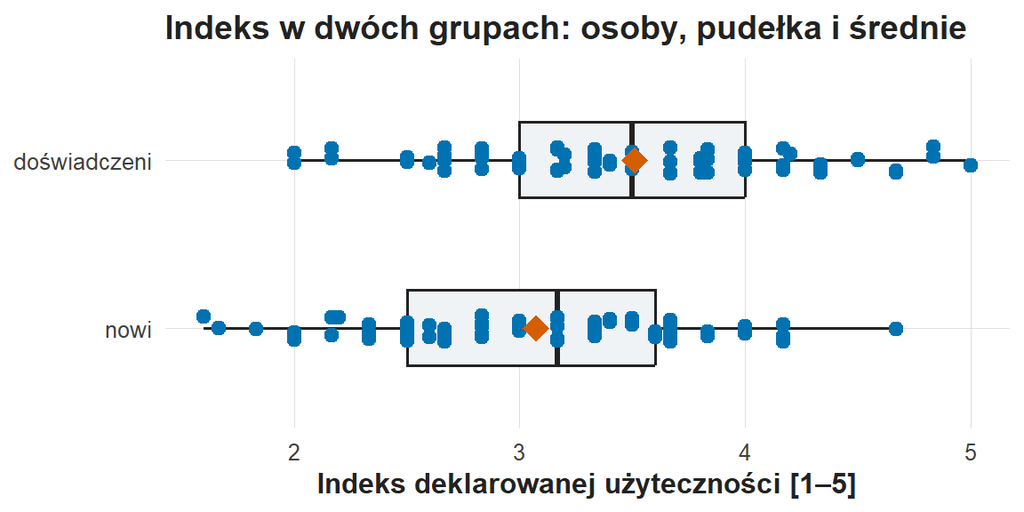

Indeks w dwóch grupach: osoby, pudełka i średnie. Oś pozioma: indeks 1–5; punkty: indeksy wszystkich osób. Doświadczeni: pudełko od 3,0 do 4,0, mediana 3,50, romb średniej przy 3,51. Nowi: pudełko od 2,5 do 3,6, mediana 3,17, romb średniej przy 3,07. Pudełka nakładają się między 3,0 a 3,6.

```r
rozklad <- pokaz_wykres(wykres_grup)
print(rozklad)
```

Punkty poza wąsami pozostają w danych. Pudełka opisują zróżnicowanie osób; niepewność średnich opisuje przedział różnicy (LEARN 3). Wykres „Histogramy gęstości indeksu w dwóch grupach” przedstawia kształt obu rozkładów na wspólnej osi.

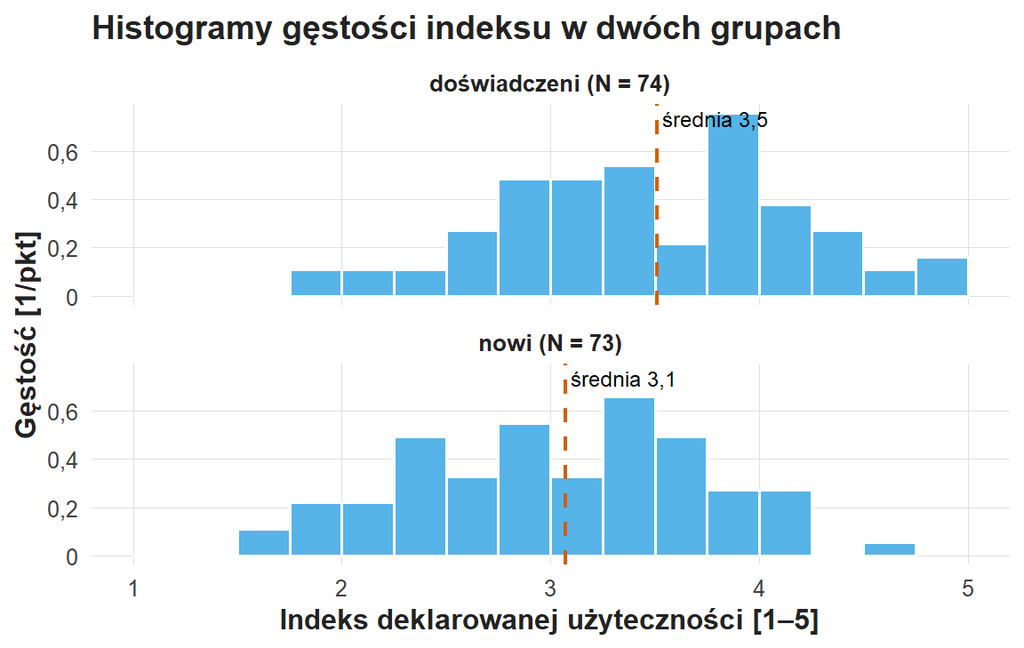

Histogramy gęstości indeksu w dwóch grupach, przedziały po 0,25 punktu. Oś pozioma: indeks 1–5; oś pionowa: gęstość na punkt. Doświadczeni (N = 74): najwyższy słupek nad przedziałem od 3,75 do 4, linia średniej przy 3,5. Nowi (N = 73): najwyższy słupek nad przedziałem od 3,25 do 3,5, linia średniej przy 3,1. Indeksy doświadczonych leżą od 2,0 do 5,0, a nowych od 1,6 do 4,67.

```r
gestosci <- pokaz_wykres(wykres_gestosci)
print(gestosci)
```

Rozkłady nakładają się w szerokim zakresie. Prawdopodobieństwo przewagi $\theta$ opisuje nakładanie jedną liczbą (wykład W04):

$$\hat\theta=\frac{1}{n_1n_2}\sum_{i=1}^{n_1}\sum_{j=1}^{n_2}\Big[\mathbb 1(x_{2j}>x_{1i})+\tfrac12\,\mathbb 1(x_{2j}=x_{1i})\Big]=0{,}310+\tfrac12\cdot0{,}046=0{,}333,$$

gdzie $\mathbb 1(\cdot)$ przyjmuje 1 przy spełnionym warunku i 0 w pozostałych parach. W 33% par (nowy, doświadczony) wyższą ocenę ma osoba nowa. Wniosek grupowy opisuje przesunięcie rozkładów, a decyzja o indywidualnej pomocy wymaga informacji o osobie.

**Wzorzec zapisu opisu dwóch grup (APA).**

> Doświadczeni użytkownicy (*n* = 74) uzyskali średni indeks *M* = 3,51 (*SD* = 0,70; *Mdn* = 3,50), a nowi (*n* = 73; 1 brak) *M* = 3,07 (*SD* = 0,69; *Mdn* = 3,17). Rozkłady grup w dużej części się nakładają: w 33% par (nowy, doświadczony) wyższą ocenę ma osoba nowa, $\hat\theta=0{,}33$.

# LEARN 2: test Welcha — od różnicy do statystyki

Oszacowana różnica wynosi:

$$\widehat\Delta=3{,}072-3{,}510=-0{,}438\ \text{punktu}.$$

Wynik ujemny oznacza średni indeks nowych niższy o 0,438 punktu.

W C05 druga strona porównania była ustaloną liczbą; w C06 obie średnie pochodzą z prób. Błąd standardowy różnicy niezależnych średnich wynosi:

$$SE(\widehat\Delta)=\sqrt{\frac{s_2^2}{n_2}+\frac{s_1^2}{n_1}}=\sqrt{0{,}00646+0{,}00669}=0{,}115 .$$

Każdy składnik pod pierwiastkiem jest oszacowaną wariancją średniej grupowej; wariancje się sumują, bo grupy są niezależne. Pomiary sparowane wymagają wzoru różnic w parach.

## Liczebność i rozrzut

Większe SD grupy zwiększa jej wkład do niepewności, a większe $n$ zmniejsza wkład, gdy przybywa niezależnych osób. Precyzja porównania zależy od obu liczebności:

$$SE=s\sqrt{\frac1{n_1}+\frac1{n_2}}:\qquad s=1:\ \ n=10\ \text{i}\ 100\ \Rightarrow\ 0{,}332;\qquad n=55\ \text{i}\ 55\ \Rightarrow\ 0{,}191 .$$

Przy tych samych 110 osobach układ 10 i 100 daje SE o 74% większe niż układ 55 i 55, więc raport podaje obie liczebności.

## Statystyka t Welcha i stopnie swobody

$$t_W=\frac{\widehat\Delta-0}{SE(\widehat\Delta)}=\frac{-0{,}438}{0{,}115}=-3{,}822,\qquad
\nu=\frac{\left(\frac{s_1^2}{n_1}+\frac{s_2^2}{n_2}\right)^2}{\frac{(s_1^2/n_1)^2}{n_1-1}+\frac{(s_2^2/n_2)^2}{n_2-1}}=144{,}98 .$$

Jednostki punktów się skracają, więc t jest liczbą bez jednostki. Stopnie swobody $\nu$ są parametrem przybliżenia Welcha i mogą być niecałkowite.

Tabela „Test Welcha — różnica grupy 2 minus grupy 1” podaje różnicę −0,438, SE 0,115, t = −3,822, df = 144,98 i p = 0,0002. Znak t jest zgodny ze znakiem różnicy.

```r
test <- test_porownania(wynik)
print(test)
```

**Test Welcha — różnica grupy 2 minus grupy 1**

| Różnica | SE | t | df | p |
| --- | --- | --- | --- | --- |
| -0,438 | 0,115 | -3,822 | 144,983 | 0,0002 |

Wartość p = 0,000196 jest dwustronną oceną skrajności t przy $H_0$ i założeniach procedury. Wykres „Rozkład t(144,98) i obserwowane t = −3,822” przedstawia rozkład odniesienia.

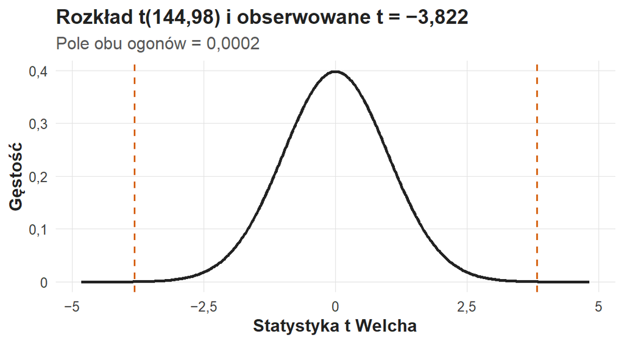

Rozkład t(144,98) i obserwowane t = −3,822. Oś pozioma: statystyka t Welcha; oś pionowa: gęstość. Krzywa jest symetryczna wokół 0; linie przerywane przy −3,822 i 3,822 leżą w ogonach, a pole obu ogonów wynosi 0,0002.

```r
rozklad_t <- pokaz_wykres(wykres_t)
print(rozklad_t)
```

Welch dopuszcza różne wariancje grup i wymaga niezależności obserwacji. Dla małych prób silna skośność i wpływowe obserwacje osłabiają przybliżenie. Niezależność i jakość pomiaru wynikają z projektu.

## Oryginalny wydruk

Skrypt wywołuje test w jawnej kolejności: najpierw wyniki grupy 2, potem grupy 1, więc estymata, statystyka i przedział mają jeden kierunek. Kolejność grup ustala argument funkcji, a opis ją powtarza.

```r
wydruk <- oryginal_testu(wynik)
print(wydruk)
```

```
    Welch Two Sample t-test

data:  b and a
t = -3.8219, df = 144.98, p-value = 0.0001959
alternative hypothesis: true difference in means is not equal to 0
95 percent confidence interval:
 -0.6648408 -0.2116000
sample estimates:
mean of x mean of y
 3.071689  3.509910
```

Odwrócenie argumentów zachowuje dwustronne p i zmienia znak t oraz przedziału. Grupę odniesienia wskazuje kod i opis analizy.

**Wzorzec zapisu testu Welcha (APA).**

> Średni indeks nowych był niższy niż doświadczonych o 0,438 punktu, *t*(144,98) = −3,82, *p* < 0,001 (dwustronny test *t* Welcha).

# LEARN 3: wielkość efektu i przedział różnicy

$$CI_{95\%}(\Delta)=
\left[\widehat\Delta-t_{0{,}975;\nu}SE,\;
\widehat\Delta+t_{0{,}975;\nu}SE\right].$$

W środku przedziału leży różnica −0,438 punktu. Tabela „95% przedziały różnicy średnich” podaje przedział Welcha od −0,665 do −0,212 i przedział bootstrapowy od −0,659 do −0,227. Oba końce przedziału Welcha są ujemne: średnia nowych jest niższa od średniej doświadczonych w modelu Welcha.

```r
przedzial <- przedzial_porownania(wynik)
print(przedzial)
```

**95% przedziały różnicy średnich**

| Metoda | Estymata | Dolna granica | Górna granica |
| --- | --- | --- | --- |
| Welch | -0,438 | -0,665 | -0,212 |
| Bootstrap w grupach | -0,438 | -0,659 | -0,227 |

Przedział dotyczy różnicy średnich grupowych w punktach indeksu. Leży w całości poniżej zera, co w parze „test Welcha–przedział Welcha” odpowiada p < 0,05; przyczynę różnicy ocenia projekt.

## Dwa kierunki tej samej różnicy

Dla kierunku doświadczeni minus nowi estymata wynosi +0,438. Odwrócenie kierunku zmienia znaki i kolejność końców: $[L;U]\to[-U;-L]$, czyli [0,212; 0,665]. Tabela „Dwa kierunki tej samej różnicy” zestawia oba poprawne opisy tych samych danych.

```r
kierunek <- kierunek_porownania()
print(kierunek)
```

**Dwa kierunki tej samej różnicy**

| Kierunek | Różnica [pkt] | t | Dolna granica | Górna granica |
| --- | --- | --- | --- | --- |
| Nowi minus doświadczeni | -0,438 | -3,822 | -0,665 | -0,212 |
| Doświadczeni minus nowi | 0,438 | 3,822 | 0,212 | 0,665 |

Ćwiczenie stosuje kierunek nowi minus doświadczeni także w CHALLENGE, gdzie zmieniają się dane i jednostka. Znak różnicy odpowiada średnim z danych.

## Efekt standaryzowany g Hedgesa

Efekt naturalny odpowiada na pytanie „ile punktów”. Efekt standaryzowany dzieli różnicę przez łączone SD osób:

$$s_p=\sqrt{\frac{(n_1-1)s_1^2+(n_2-1)s_2^2}{n_1+n_2-2}},
\quad d=\frac{\widehat\Delta}{s_p},
\quad g=Jd,\quad J=1-\frac{3}{4(n_1+n_2)-9}.$$

Tabela „Efekt surowy i standaryzowany” podaje: $s_p=0{,}695$, $d=-0{,}630$, $J=0{,}995$ i $g=-0{,}627$. Łączone SD 0,695 opisuje rozrzut osób, a SE 0,115 — niepewność różnicy. Znak g zachowuje kierunek różnicy, bo mianownik i korekta są dodatnie.

```r
efekt <- efekt_porownania(wynik)
print(efekt)
```

**Efekt surowy i standaryzowany**

| Miara | Wartość |
| --- | --- |
| Różnica średnich | -0,438 |
| Łączone SD s_p | 0,695 |
| d = różnica / s_p | -0,630 |
| Korekta J | 0,995 |
| g Hedgesa = J · d | -0,627 |

Wartość g = −0,627 oznacza różnicę równą 0,63 łączonego SD osób, po korekcie małopróbkowej. Interpretacja praktyczna odwołuje się do treści pozycji i punktów indeksu: do zrozumiałości filtrów, lokalizacji dokumentu i oceny wsparcia.

**Wzorzec zapisu efektu i przedziału różnicy (APA).**

> Różnica nowi minus doświadczeni wyniosła −0,438 punktu, 95% CI [−0,665; −0,212], *g* = −0,63; oba końce przedziału są ujemne.

# LEARN 4: bootstrap i tasowanie — dwa różne losowania

Bootstrap dwóch grup losuje ze zwracaniem osobno w każdej grupie: w replice $b$ losuje 74 osoby doświadczone z ich próby i 73 nowe z ich próby, a potem liczy

$$\widehat\Delta^*_b=\bar x^*_{2,b}-\bar x^*_{1,b},\qquad CI^{\text{boot}}_{95\%}=\left[\widehat\Delta^*_{(0{,}025)},\ \widehat\Delta^*_{(0{,}975)}\right],$$

gdzie $\widehat\Delta^*_{(q)}$ jest kwantylem rzędu $q$ różnic z $B=1999$ replik.

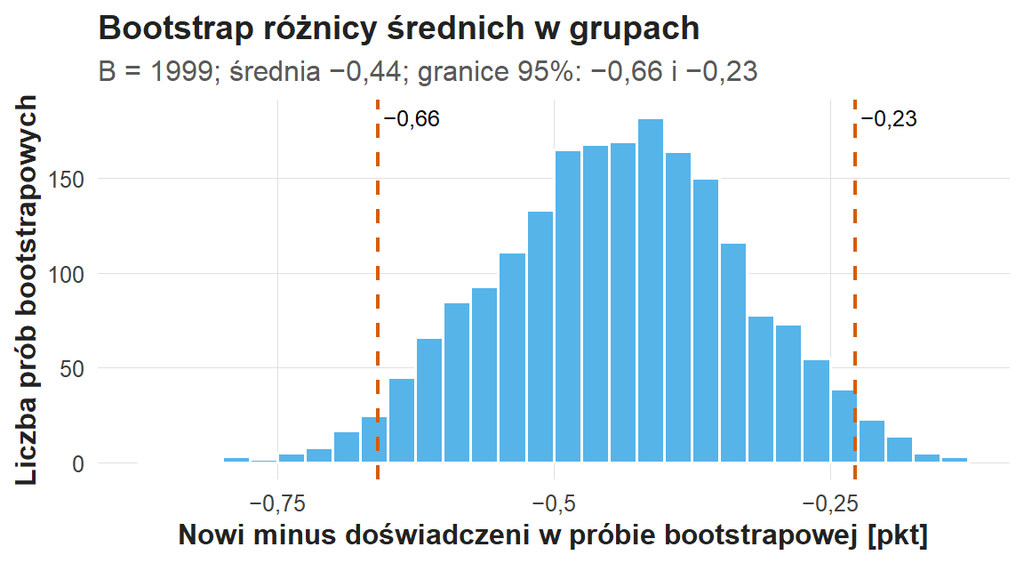

Bootstrap różnicy średnich w grupach: histogram 1999 różnic nowi minus doświadczeni, przedziały po 0,025 punktu. Oś pozioma: różnica w próbie bootstrapowej; oś pionowa: liczba prób. Różnice leżą od −0,86 do −0,13 wokół −0,44; linie przerywane przy −0,66 i −0,23 wyznaczają percentylowy przedział 95%.

```r
bootstrap <- pokaz_wykres(wykres_boot)
print(bootstrap)
```

Rozkład replik skupia się wokół różnicy z danych, −0,438. Losowanie osobno w grupach zachowuje liczebności grup i odtwarza niepewność dwóch oddzielnych średnich.

Percentylowy przedział [−0,659; −0,227] jest bliski przedziałowi Welcha [−0,665; −0,212]; granice różnią się zasadą konstrukcji i skończoną liczbą losowań.

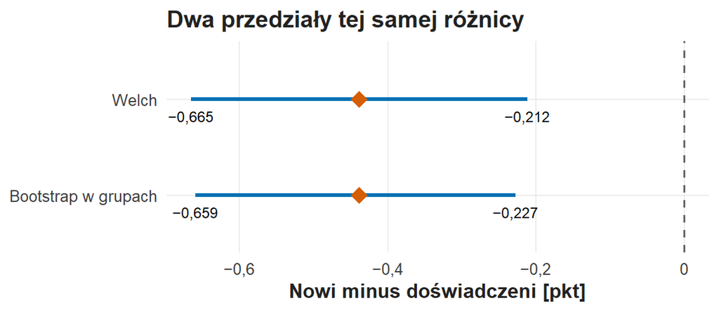

Dwa przedziały tej samej różnicy nowi minus doświadczeni. Oś pozioma: różnica w punktach. Welch: od −0,665 do −0,212; bootstrap w grupach: od −0,659 do −0,227; romby przy −0,438; linia przerywana zera leży na prawo od obu odcinków.

```r
przedzialy <- pokaz_wykres(wykres_ci)
print(przedzialy)
```

Oba przedziały korzystają z tych samych 147 osób i dzielą ograniczenia pomiaru oraz doboru.

## Tasowanie zmienia powiązanie wyniku z etykietą

Tasowanie łączy obserwowane indeksy i losowo przestawia etykiety nowych oraz doświadczonych, zachowując liczebności 74 i 73. W każdym przestawieniu powstaje różnica w tym samym kierunku. Tasowanie zmienia przypisanie wyników do grup; statystyką jest różnica średnich w punktach.

$$p_{\mathrm{perm}}=
\frac{1+\#\{b:\ |\widehat\Delta_b^*|
\geq|\widehat\Delta_{\mathrm{obs}}|\}}{B+1}.$$

Tabela „Tasowanie etykiet grup” podaje różnicę obserwowaną −0,438, 1 przestawienie z $|\widehat\Delta_b^*|\ge0{,}438$ i B = 1999, więc $p_{\mathrm{perm}}=(1+1)/2000=0{,}001$. Wzór obejmuje jedynkę w liczniku i remisy w warunku $\ge$.

```r
permutacja <- permutacja_porownania(wynik)
print(permutacja)
```

**Tasowanie etykiet grup**

| Różnica obserwowana | Tasowania co najmniej tak skrajne (k) | B | p_perm |
| --- | --- | --- | --- |
| -0,438 | 1 | 1999 | 0,0010 |

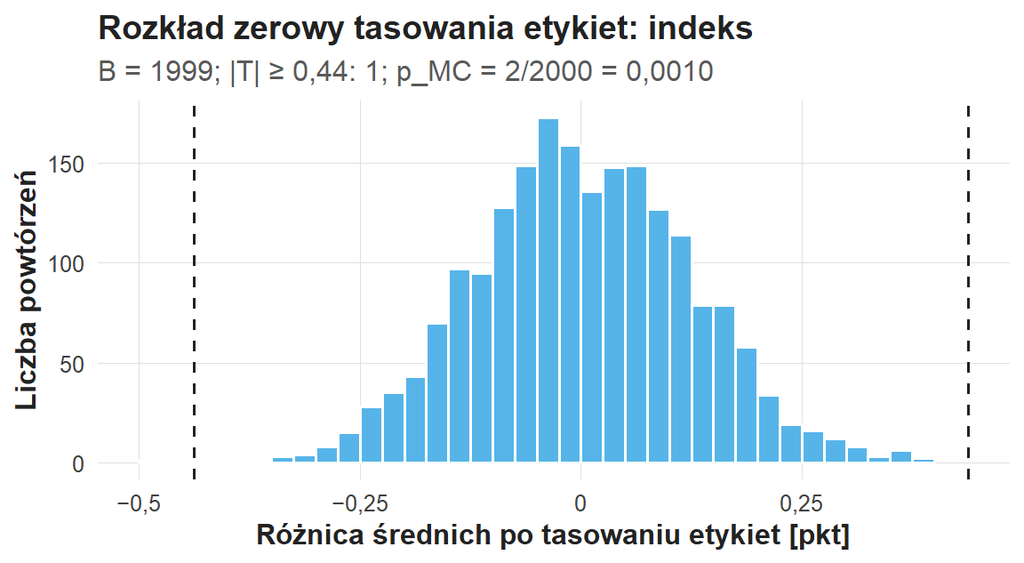

Rozkład zerowy tasowania etykiet dla indeksu: histogram 1999 różnic po przestawieniu etykiet, przedziały po 0,025 punktu. Oś pozioma: różnica średnich po tasowaniu; oś pionowa: liczba powtórzeń. Histogram jest symetryczny wokół zera i leży od −0,49 do 0,40; linie przerywane przy −0,438 i 0,438 obejmują prawie wszystkie powtórzenia, a jedno powtórzenie leży na liniach lub dalej.

```r
rozklad_zerowy <- pokaz_wykres(wykres_zerowy)
print(rozklad_zerowy)
```

Histogram skupia się wokół zera, bo losowe etykiety rozbijają systematyczną różnicę grup. Wartości p Welcha (0,0002) i $p_{\mathrm{perm}}$ (0,001) różnią się rozdzielczością: najmniejsze $p_{\mathrm{perm}}$ przy B = 1999 wynosi 0,0005.

## Wymienialność: warunek tasowania etykiet

Wymienialność wymaga wspólnego rozkładu grup przy $H_0$: wtedy etykiety można przestawiać. Przy różnych wariancjach grup tasowanie surowej różnicy średnich zmienia poziom $\alpha$, więc przy równych średnich i różnych rozrzutach pierwszeństwo ma statystyka Welcha.

Grupy powstały poza kontrolą badacza, więc odczyt tasowania zależy od modelu wymienialności. Znaczenie dozwolonych przestawień i struktury danych opisują [Winkler i współautorzy (2014)](https://pmc.ncbi.nlm.nih.gov/articles/PMC4010955/).

Przy różnych wynikach dwóch procedur raport sprawdza pytanie, statystykę, N, wariancje, schemat losowania i B; tę samą kontrolę wykonuje przy wynikach zgodnych.

**Wzorzec zapisu bootstrapu i tasowania (APA).**

> Percentylowy przedział bootstrapowy różnicy (*B* = 1999, losowanie osobno w grupach) wyniósł [−0,659; −0,227]. Tasowanie etykiet grup (*B* = 1999) dało *p*<sub>perm</sub> = 0,001, ponieważ 1 z 1999 przestawień było co najmniej tak skrajne jak obserwowana różnica; wynik zakłada wymienialność grup przy *H*<sub>0</sub>.

# LEARN 5: od tabeli do akapitu wynikowego

**Wzorzec zapisu wyniku porównania (APA).**

> Nowi użytkownicy mieli średni indeks *M* = 3,07 (*SD* = 0,69; *n* = 73), a doświadczeni *M* = 3,51 (*SD* = 0,70; *n* = 74). Różnica nowi minus doświadczeni wyniosła −0,438 punktu, 95% CI [−0,665; −0,212], *t*(144,98) = −3,82, *p* < 0,001, *g* = −0,63.

> Percentylowy przedział bootstrapowy różnicy wyniósł [−0,659; −0,227], a tasowanie etykiet (*B* = 1999) dało *p*<sub>perm</sub> = 0,001 przy modelu wymienialności. Wynik opisuje niższą deklarowaną użyteczność katalogu u nowych użytkowników.

Wzorzec przedstawia strukturę odczytu; w CHALLENGE inny scenariusz ma inne grupy, treść wyniku i kierunek. Wskazanie elementu katalogu do poprawy wymaga analizy pozycji i obserwacji zadań.

## Czas wykonania: drugi wskaźnik i szeroki przedział

Indeks jest deklaracją oceny usługi, a czas — obserwowanym wynikiem zadania. Przejście do czasu zmienia jednostkę, interpretację znaku i N.

Tabela „Opis grup [min]” zachowuje kierunek nowi minus doświadczeni i podaje: doświadczeni — N = 70 ważnych czasów, 4 braki, średnia 9,97, SD 6,02 minuty; nowi — N = 72, 2 braki, średnia 10,28, SD 5,72 minuty. N różni się od N analizy indeksu.

```r
opis_czasu <- opis_porownania(wynik_czas, jednostka='min')
print(opis_czasu)
```

**Opis grup [min]**

| Grupa | N | Braki | Średnia | SD | Mediana | IQR |
| --- | --- | --- | --- | --- | --- | --- |
| doświadczeni | 70 | 4 | 9,971 | 6,024 | 7,9 | 6,675 |
| nowi | 72 | 2 | 10,281 | 5,723 | 8,5 | 6,500 |

Różnica średnich wynosi 0,31 minuty, czyli 18,5 sekundy. Dłuższy czas może oznaczać trudność albo staranność; interpretacja wymaga zestawienia z powodzeniem.

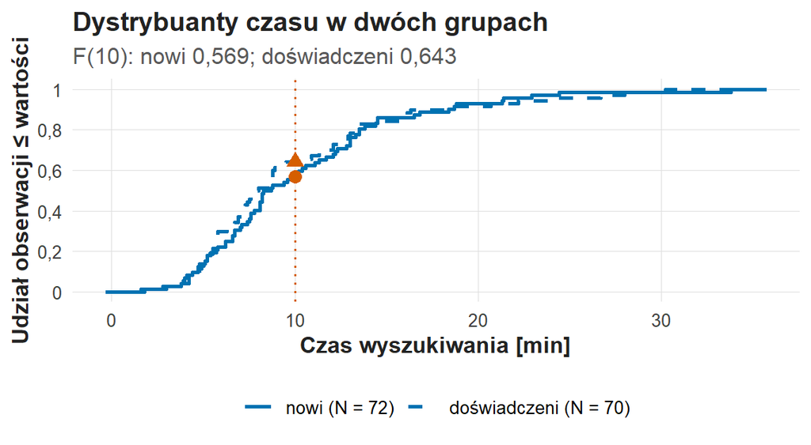

Dystrybuanty czasu w dwóch grupach. Oś pozioma: czas wyszukiwania w minutach; oś pionowa: udział czasów mniejszych lub równych wartości. Linia ciągła: nowi (N = 72), linia przerywana: doświadczeni (N = 70). Krzywe przeplatają się; przy 10 minutach (linia kropkowana) dystrybuanta doświadczonych wynosi 0,643, a nowych 0,569.

```r
dystrybuanty <- pokaz_wykres(wykres_ecdf_czasu)
print(dystrybuanty)
```

Tabele „Test Welcha”, „95% przedziały różnicy” i „Tasowanie etykiet grup” podają dla czasu: SE 0,987 minuty, t = 0,313, df = 139,12, p = 0,754; przedział Welcha od −1,64 do 2,26 minuty, bootstrapowy od −1,60 do 2,21; 1544 z 1999 przestawień z $|\widehat\Delta^*|\ge0{,}309$, czyli $p_{\mathrm{perm}}=0{,}773$.

```r
porownanie_czasu <- czas_do_raportu(wynik_czas)
print(porownanie_czasu)
```

**Test Welcha**

| Różnica | SE | t | df | p |
| --- | --- | --- | --- | --- |
| 0,309 | 0,987 | 0,313 | 139,12 | 0,7545 |

**95% przedziały różnicy**

| Metoda | Estymata | Dolna granica | Górna granica |
| --- | --- | --- | --- |
| Welch | 0,309 | -1,641 | 2,260 |
| Bootstrap w grupach | 0,309 | -1,601 | 2,208 |

**Tasowanie etykiet grup**

| Różnica obserwowana | Tasowania co najmniej tak skrajne (k) | B | p_perm |
| --- | --- | --- | --- |
| 0,309 | 1544 | 1999 | 0,7725 |

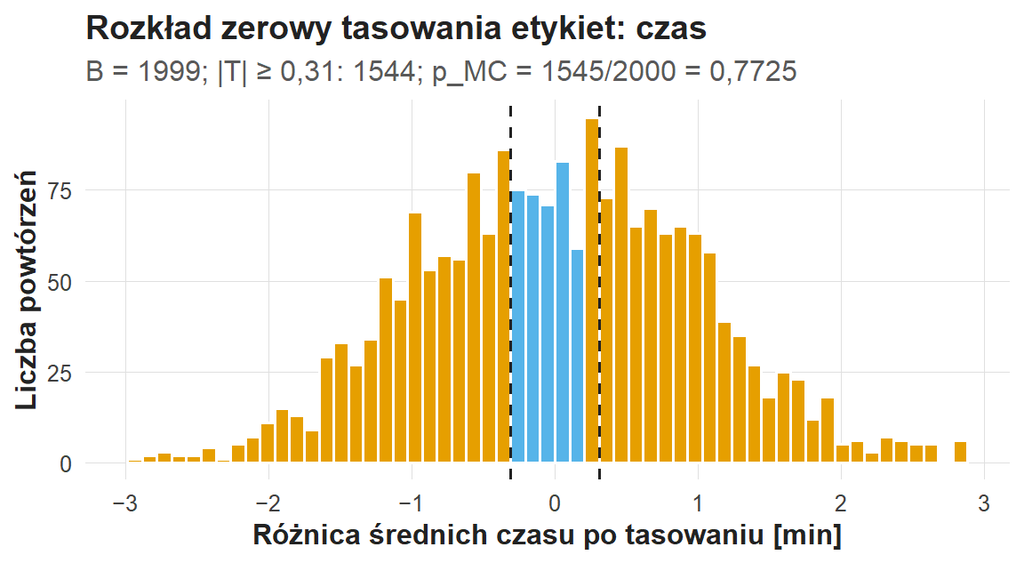

Rozkład zerowy tasowania etykiet dla czasu: histogram 1999 różnic średnich po przestawieniu etykiet. Oś pozioma: różnica w minutach; oś pionowa: liczba powtórzeń. Histogram leży od −2,98 do 2,85 minuty wokół zera; linie przerywane przy −0,309 i 0,309 obejmują wąski środek, a wyróżnione słupki na liniach i poza nimi zawierają 1544 powtórzenia.

```r
zerowy_czasu <- pokaz_wykres(wykres_zerowy_czasu)
print(zerowy_czasu)
```

Przedział od −1,64 do 2,26 minuty opisuje zakres różnic zgodnych z danymi: krótszy i dłuższy średni czas nowych. Tasowanie daje $p_{\mathrm{perm}}=0{,}773$, zgodne z p Welcha 0,754.

Porównanie dwóch relacji wymaga testu różnicy dwóch relacji; dwa p dotyczą dwóch wskaźników o różnych jednostkach i precyzji. Zdanie o „działaniu doświadczenia na oceny i braku działania na czas” wymaga więc osobnej analizy.

## Podobny czas i różna skuteczność

Dwie grupy mogą mieć podobny średni czas i różną skuteczność: jedna częściej kończy szybko błędną odpowiedzią, druga pracuje dłużej i osiąga sukces. Rozróżnienie mechanizmów wymaga zestawienia czasu z powodzeniem.

Powody przerwania pozostają poza danymi S02; powodzenie w grupach opisuje ćwiczenie C07 (Kategorie i zachowanie). Raport oddziela obliczoną statystykę od hipotetycznego wyjaśnienia.

**Wzorzec zapisu wyniku z przedziałem obejmującym zero (APA).**

> Średni czas nowych był dłuższy o 0,31 min, 95% CI [−1,64; 2,26], *t*(139,12) = 0,31, *p* = 0,754; tasowanie etykiet (*B* = 1999) dało *p*<sub>perm</sub> = 0,773. Przedział obejmuje krótszy i dłuższy średni czas nowych, więc kierunek i wielkość różnicy czasu pozostają nieustalone.

# CHALLENGE — samodzielna analiza czasu

Dwie grupy po dwanaście osób wykonują to samo zadanie w tym samym repozytorium. Grupy oznaczają wcześniejsze doświadczenie i powstały bez przydziału do szkolenia. Zarejestrowano minuty do zakończenia próby, niezależnie od poprawności; zbiór zawiera wyłącznie czas, a wszystkie czasy są ważne i syntetyczne. Pytanie dotyczy różnicy średnich czasów w kierunku nowi minus doświadczeni. Interpretacja obu testów przyjmuje niezależność osób, a tasowanie dodatkowo — wymienialność rozkładów przy hipotezie zerowej.

Funkcja `porownaj_grupy()` w bloku CHALLENGE 1 przyjmuje tabelę danych, nazwę kolumny wyniku, ziarno losowania i domyślnie B = 1999 losowań. Zwraca opis grup, test Welcha, efekt, dwa przedziały i wynik tasowania w obiekcie `porownanie`, z którego korzystają bloki CHALLENGE 2–5.

Każde z pięciu zadań ma ten sam układ:

1. **Zadanie** — jedno zdanie z przedmiotem opisu.
2. **Blok R** — uruchom go; wynik zawiera wszystkie liczby potrzebne do odpowiedzi.
3. **Wskazówki** — gdzie w wyniku szukać informacji, jak ją nazwać i wzór zdania do uzupełnienia.
4. **W akapicie wymagane** — elementy, które sprawdza prowadzący.
5. **Twój akapit** — pole odpowiedzi w ramce: znacznik w nawiasie kwadratowym zastępujesz własnym tekstem, a linie komentarza nad nim i pod nim pozostawiasz bez zmian.

Akapit liczy 3–5 zdań zwykłego tekstu, bez kodu R. Liczby przepisujesz z wyniku bloku, z jednostką, symbolem i mianownikiem.

## CHALLENGE 1: Dwie grupy w liczbach

**Zadanie:** porównaj czas obu grup liczebnością, średnią, SD, minimum i maksimum oraz wskaż dane potrzebne do oceny skuteczności.

```r
porownanie <- porownaj_grupy(repozytorium, zmienna='czas_min', ziarno=202628L)
opis <- opis_porownania(porownanie, jednostka='min', wykres=TRUE)
print(opis)
```

**Opis grup [min]**

| Grupa | N | Średnia | SD | Minimum | Maksimum |
| --- | --- | --- | --- | --- | --- |
| doświadczeni | 12 | 9,00 | 2,296 | 5 | 13 |
| nowi | 12 | 11,25 | 2,734 | 7 | 16 |

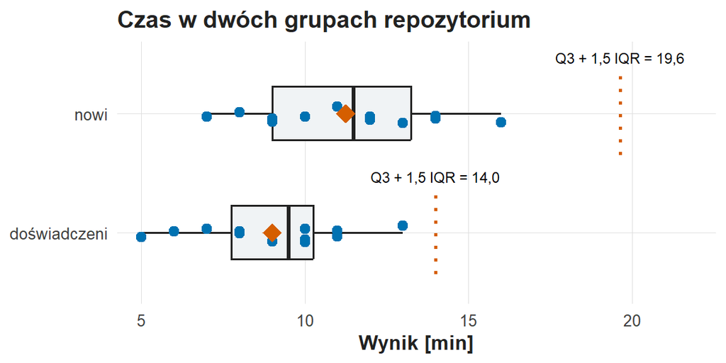

Czas w dwóch grupach repozytorium. Oś pozioma: czas w minutach; punkty: czasy wszystkich osób; pudełko: kwartyle i mediana; romb: średnia grupy; linia kropkowana: granica Q3 + 1,5 IQR.

Blok wyświetla tabelę „Opis grup [min]” (N, średnia, SD, minimum i maksimum) oraz wykres „Czas w dwóch grupach repozytorium” z osobami, pudełkami i średnimi.

*Wskazówki:*

- Minimum i maksimum to wyniki pojedynczych osób; średnia i SD opisują całą grupę.
- Z wykresu odczytaj, czy pudełka się nakładają: nakładanie oznacza, że część nowych osób szukała krócej niż część doświadczonych.
- Zbiór zawiera wyłącznie czas; ocena skuteczności wymaga wyniku 0/1 każdej osoby według kryterium poprawnej publikacji.
- Wzorzec APA: „Doświadczeni (*n* = [..]) szukali średnio *M* = [..] min (*SD* = [..] min; od [..] do [..] min), a nowi (*n* = [..]) *M* = [..] min (*SD* = [..] min; od [..] do [..] min)”.

*W akapicie wymagane:* (i) N obu grup; (ii) średnie i SD z minutami; (iii) minima i maksima jako wyniki pojedynczych osób; (iv) jedna cecha wykresu; (v) dane potrzebne do oceny skuteczności.

**Twój akapit S01.** Znacznik w nawiasie kwadratowym zastąp własnym tekstem.

## CHALLENGE 2: Pytanie, H0 i wynik klasyczny

**Zadanie:** zapisz hipotezę zerową porównania i odczytaj wynik testu Welcha z różnicą, SE, t, df i p.

```r
test <- test_porownania(porownanie)
print(test)
```

**Test Welcha — różnica grupy 2 minus grupy 1**

| Różnica | SE | t | df | p |
| --- | --- | --- | --- | --- |
| 2,25 | 1,031 | 2,183 | 21,361 | 0,0403 |

Blok wyświetla tabelę „Test Welcha — różnica grupy 2 minus grupy 1” z różnicą, SE, t, df i p.

*Wskazówki:*

- $H_0\colon \mu_{\text{nowi}}-\mu_{\text{doświadczeni}}=0$: średnie czasy w obu populacjach są równe; alternatywa dwustronna obejmuje oba kierunki.
- Porównanie jest niezależne, bo każda osoba należy do jednej grupy i ma jeden pomiar.
- t = różnica / SE: znak t jest zgodny ze znakiem różnicy, a df Welcha może być niecałkowite.
- Wniosek jest warunkowy: p opisuje skrajność wyniku przy prawdziwej $H_0$ i założeniach testu.
- Wzorzec APA: „Średni czas nowych był [dłuższy/krótszy] niż doświadczonych o [..] min (*SE* = [..] min), *t*([df]) = [..], *p* = [..] (dwustronny test *t* Welcha)”.

*W akapicie wymagane:* (i) $H_0$ symbolami i słowami; (ii) uzasadnienie porównania niezależnego; (iii) różnica i SE z minutami; (iv) t, df i p; (v) wniosek sformułowany warunkowo względem modelu.

**Twój akapit S02.** Znacznik w nawiasie kwadratowym zastąp własnym tekstem.

## CHALLENGE 3: Wynik tasowania etykiet

Drugie obliczenie zachowuje te same czasy i losowo przypisuje etykiety grup z zachowaniem liczebności; powstaje rozkład odniesienia dla obserwowanej różnicy.

**Zadanie:** odczytaj wynik tasowania etykiet, porównaj go z testem Welcha i nazwij założenie oraz granicę wniosku.

```r
permutacja <- tasowanie_i_welch(porownanie)
print(permutacja)
```

**Tasowanie etykiet grup**

| Różnica obserwowana | Tasowania co najmniej tak skrajne (k) | B | p_perm |
| --- | --- | --- | --- |
| 2,25 | 71 | 1999 | 0,0360 |

**Test Welcha tego samego pytania**

| Różnica | SE | t | df | p |
| --- | --- | --- | --- | --- |
| 2,25 | 1,031 | 2,183 | 21,361 | 0,0403 |

Blok wyświetla tabelę „Tasowanie etykiet grup” (różnica obserwowana, liczba tasowań co najmniej tak skrajnych k, B i $p_{\mathrm{perm}}$) oraz tabelę „Test Welcha tego samego pytania”.

*Wskazówki:*

- $p_{\mathrm{perm}}=(k+1)/(B+1)$: podstaw k i B z tabeli.
- Skrajność dwustronna liczy tasowania z różnicą co najmniej tak odległą od zera jak obserwowana, w obu kierunkach.
- Oba testy dotyczą tego samego pytania i tych samych 24 osób; porównaj p Welcha i $p_{\mathrm{perm}}$.
- Wymienialność zakłada wspólny rozkład grup przy $H_0$; grupy doświadczenia są obserwacyjne, więc wynik opisuje związek doświadczenia z czasem.
- Wzorzec APA: „Tasowanie etykiet grup (*B* = [..]) dało *p*<sub>perm</sub> = ([k] + 1)/([B] + 1) = [..], zbliżone do wyniku testu Welcha (*p* = [..]); wynik zakłada wymienialność grup przy *H*<sub>0</sub>”.

*W akapicie wymagane:* (i) k, B i $p_{\mathrm{perm}}$ z rachunkiem; (ii) reguła dwustronnej skrajności; (iii) porównanie z p Welcha dla tego samego pytania i N; (iv) założenie wymienialności; (v) granica wniosku wynikająca z obserwacyjnych grup.

**Twój akapit S03.** Znacznik w nawiasie kwadratowym zastąp własnym tekstem.

## CHALLENGE 4: Wielkość różnicy i precyzja

**Zadanie:** opisz różnicę czasu z dwoma 95% przedziałami i g oraz wskaż informację potrzebną do oceny praktycznej wagi minut.

```r
efekt <- podsumowanie_porownania(porownanie, jednostka='min')
print(efekt)
```

**Efekty**

| Miara | Wartość |
| --- | --- |
| Różnica średnich | 2,250 |
| Łączone SD s_p | 2,525 |
| d = różnica / s_p | 0,891 |
| Korekta J | 0,966 |
| g Hedgesa = J · d | 0,860 |

**95% przedziały różnicy**

| Metoda | Estymata | Dolna granica | Górna granica |
| --- | --- | --- | --- |
| Welch | 2,25 | 0,109 | 4,391 |
| Bootstrap w grupach | 2,25 | 0,333 | 4,167 |

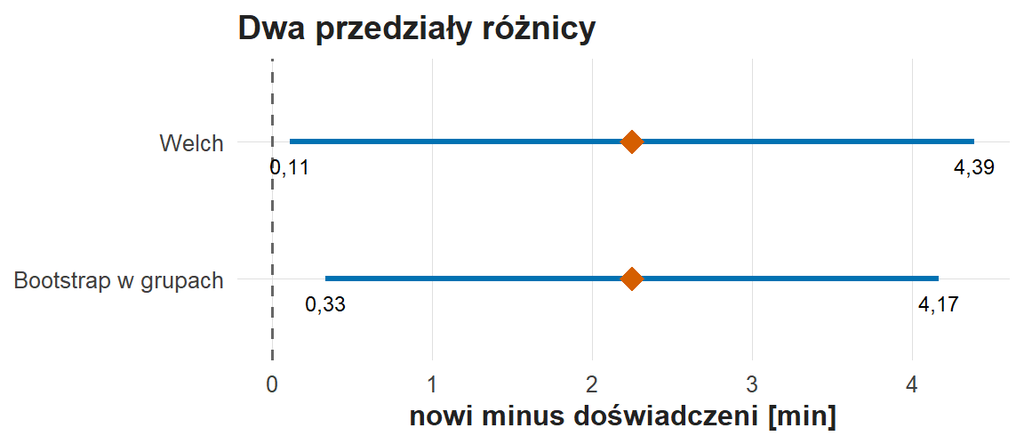

Dwa przedziały różnicy średnich czasu nowi minus doświadczeni w minutach: Welch i bootstrap w grupach. Romb oznacza estymatę, liczby przy końcach odcinków — granice przedziału, a linia przerywana — zero.

Blok wyświetla tabelę „Efekty” (różnica średnich, łączone SD, d, korekta J i g Hedgesa), tabelę „95% przedziały różnicy” (Welch i bootstrap w grupach) oraz wykres „Dwa przedziały różnicy”.

*Wskazówki:*

- Przedział dotyczy różnicy średnich w minutach; wartości wewnątrz przedziału Welcha są zgodne z danymi przy założeniach metody.
- Dolna granica przedziału bliska zera i górna rzędu 4 minut oznaczają szeroki zakres zgodnych różnic przy 12 osobach w grupie.
- g dzieli różnicę przez łączone SD osób i jest liczbą bez jednostki; efekt w minutach pozostaje efektem głównym.
- Praktyczną wagę minut ocenia się względem progu ustalonego przez instytucję, np. kosztu czasu przy typowym zadaniu.
- Wzorzec APA: „Różnica nowi minus doświadczeni wyniosła [..] min, 95% CI [[..]; [..]] (Welch), a percentylowy przedział bootstrapowy [[..]; [..]]; *g* = [..]”.

*W akapicie wymagane:* (i) różnica w minutach; (ii) oba 95% CI z nazwą metody; (iii) g jako efekt bez jednostki; (iv) zakres różnic zgodnych z przedziałem Welcha; (v) informacja potrzebna do oceny praktycznej wagi minut.

**Twój akapit S04.** Znacznik w nawiasie kwadratowym zastąp własnym tekstem.

## CHALLENGE 5: Poprawiona rekomendacja

Szkic raportu brzmi: „Doświadczenie spowodowało wzrost kompetencji, dlatego szkolenie zagwarantuje szybsze i skuteczniejsze szukanie”. Dane pochodzą z porównania obserwacyjnego i zawierają wyłącznie czas.

**Zadanie:** zastąp szkic opisem różnicy czasu z liczbami obu testów i zaproponuj następne badanie.

```r
raport <- wynik_do_raportu(porownanie)
print(raport)
```

**Opis grup [min]**

| Grupa | N | Średnia | SD |
| --- | --- | --- | --- |
| doświadczeni | 12 | 9,00 | 2,296 |
| nowi | 12 | 11,25 | 2,734 |

**Test Welcha**

| Różnica | SE | t | df | p |
| --- | --- | --- | --- | --- |
| 2,25 | 1,031 | 2,183 | 21,361 | 0,0403 |

**95% przedziały różnicy**

| Metoda | Estymata | Dolna granica | Górna granica |
| --- | --- | --- | --- |
| Welch | 2,25 | 0,109 | 4,391 |
| Bootstrap w grupach | 2,25 | 0,333 | 4,167 |

**Tasowanie etykiet grup**

| Różnica obserwowana | Tasowania co najmniej tak skrajne (k) | B | p_perm |
| --- | --- | --- | --- |
| 2,25 | 71 | 1999 | 0,0360 |

**Efekt standaryzowany**

| g Hedgesa |
| --- |
| 0,86 |

Blok wyświetla tabele „Opis grup [min]”, „Test Welcha”, „95% przedziały różnicy”, „Tasowanie etykiet grup” i „Efekt standaryzowany” — komplet liczb do akapitu wynikowego.

*Wskazówki:*

- Szkic zawiera trzy błędy: przyczynę („spowodowało”) przy grupach obserwacyjnych, kompetencje przy pomiarze wyłącznie czasu i skuteczność bez wyniku 0/1.
- Opis wyniku podaje N, średnie, różnicę z przedziałem, oba testy i g.
- Następne badanie: pomiar poprawności odnalezionej publikacji albo porównanie osób losowo przydzielonych do szkolenia i grupy bez szkolenia.
- Wzorzec APA: „Nowi (*n* = [..]) szukali średnio *M* = [..] min (*SD* = [..]), a doświadczeni (*n* = [..]) *M* = [..] min (*SD* = [..]). Różnica wyniosła [..] min, 95% CI [[..]; [..]], *t*([df]) = [..], *p* = [..], *p*<sub>perm</sub> = [..], *g* = [..]. Grupy są obserwacyjne, a zbiór zawiera wyłącznie czas; ocena szkolenia wymaga [..]”.

*W akapicie wymagane:* (i) N, średnie, różnica i przedział; (ii) wyniki obu testów i g; (iii) zaobserwowana różnica oddzielona od pomysłu na badanie; (iv) ograniczenie: grupy obserwacyjne i sam czas; (v) propozycja pomiaru skuteczności albo projektu oceny szkolenia.

**Twój akapit S05.** Znacznik w nawiasie kwadratowym zastąp własnym tekstem.

# Zapis i oddanie

Sprawdź pięć własnych odpowiedzi: każda różnica ma kierunek i jednostkę, każdy przedział — nazwany parametr, a każde p — procedurę. Zapisz plik `zadanie.Rmd` w edytorze (Ctrl+S); funkcja oddania tworzy PDF z zapisanego pliku.

W konsoli wykonaj jedno polecenie. Funkcja oddania tworzy aktualny PDF, sprawdza kompletność, otwiera PDF do obejrzenia i po potwierdzeniu literą `t` wysyła go do folderu zadania prowadzącego na serwerze UJ (nc.uj.edu.pl). Nazwa pliku zawiera Twoje ID oraz nazwisko i imię.

```r
oddaj_zadanie("Z06")
```

Oddanie potwierdza komunikat z nazwą wysłanego pliku, folderem i czasem; plik `oddania.csv` w folderze `moje-badania` zapisuje także sumę SHA-256 wysłanego PDF. Po komunikacie błędu popraw wskazany problem, zapisz plik i ponownie wywołaj `oddaj_zadanie("Z06")`; nowa wersja trafia do folderu obok poprzedniej. Ocenę prowadzący przekazuje osobno.

Po potwierdzonym oddaniu możesz zamknąć projekt: Posit Cloud zachowuje folder `moje-badania` do kolejnych zajęć. Na komputerze współdzielonym wyloguj się z Posit Cloud w przeglądarce. Przy braku sieci PDF pozostaje w folderze zadania; wyślij go tym samym poleceniem po odzyskaniu połączenia, a gdy problem trwa, poproś prowadzącego o ustalenie sposobu dostarczenia pracy.

## Co jest oceniane

| Kryterium | Dowód w Twojej pracy | Odpowiedzi | Punkty |
| --- | --- | --- | --- |
| Z06.1 Pytanie, niezależność i warunki dwóch procedur | $H_0$ o różnicy średnich czasów i uzasadnienie niezależnych grup; tasowanie etykiet, dwustronna skrajność i wymienialność przy $H_0$; grupy obserwacyjne | S02, S03 | 3 |
| Z06.2 Opis grup, różnica czasu i jej niepewność | N, średnie i minima z jednostkami; różnica nowi minus doświadczeni, oba 95% CI i g; przedziały minut przypisane różnicy średnich | S01, S04 | 3 |
| Z06.3 Statystyka Welcha i wynik permutacyjny | Różnica, SE, t, df i p ze zgodnym znakiem; T, B i $p_{\mathrm{perm}}$ porównane z Welchem dla tego samego pytania i N | S02, S03 | 2 |
| Z06.4 Ostrożna rekomendacja oparta na wynikach | Własny opis N, różnicy, CI i obu testów; czas odróżniony od skuteczności, istotność od praktycznej wagi minut; ograniczenie i propozycja pomiaru | S01, S04, S05 | 2 |

Ocena dotyczy zgodności zdania z danymi. Poziomy wykonania opisuje rubryka Z06: na stronie kursu w dokumencie `rubryki/Z06.html`, a w konsoli R po poleceniu `rubryka("Z06")`.

# Rozwinięcia do powtórki — poza rdzeniem spotkania

Rozwinięcia rozwijają LEARN: pełne wyliczenie podziałów, przedziały średnich i różnicy, pary, założenie o wariancjach i redakcję wniosków. Rozwinięcia służą powtórce i pozostają poza oceną.

## Wszystkie podziały czterech osób

W demonstracji cztery osoby mają indeksy 1, 2, 4 i 5. Osoby a i b należą do doświadczonych, c i d — do nowych. Obserwowana różnica nowi minus doświadczeni wynosi $4{,}5-1{,}5=3$ punkty.

Tabela „Sześć podziałów czterech osób” podaje wszystkie sposoby wybrania dwóch osób do grupy nowych, z liczebnościami 2 i 2 oraz wszystkimi czterema wynikami. Sześć podziałów daje różnice −3, −1, 0, 0, 1 i 3 punkty.

```r
uklady <- podzialy_czterech_osob()
print(uklady)
```

**Sześć podziałów czterech osób**

| Nowi | Doświadczeni | Różnica [pkt] | Różnica co najmniej 3 od zera |
| --- | --- | --- | --- |
| a, b | c, d | -3 | tak |
| a, c | b, d | -1 | nie |
| a, d | b, c | 0 | nie |
| b, c | a, d | 0 | nie |
| b, d | a, c | 1 | nie |
| c, d | a, b | 3 | tak |

Dwa z sześciu podziałów dają bezwzględną różnicę co najmniej 3, więc $p=2/6=1/3$. Przy czterech osobach najmniejsze osiągalne p wynosi 2/6 = 1/3, także przy dużej obserwowanej różnicy.

Pełne wyliczenie daje p jako udział skrajnych układów, łącznie z obserwowanym; każdy układ ma tę samą wagę. Rozkład zerowy powstaje ze zmiany przypisania wyników do grup; przestawienie kolejności wierszy wewnątrz grupy zachowuje średnie.

## Przedziały średnich i przedział różnicy

Niepewność różnicy niezależnych średnich wynika z sumy ich wariancji:

$$SE(\bar x_B-\bar x_A)=\sqrt{SE_A^2+SE_B^2}.$$

Hipotetyczne grupy A i B mają po 100 osób, SD 1 oraz średnie 3 i 3,3 punktu. Tabele „95% przedziały średnich grup A i B” i „95% przedział różnicy B − A” podają: A — od 2,802 do 3,198, B — od 3,102 do 3,498; różnica 0,3, SE 0,1414, przedział od 0,021 do 0,579.

```r
przedzialy_grup <- przedzialy_grup_demo()
print(przedzialy_grup)
```

**95% przedziały średnich grup A i B**

| Grupa | N | Średnia | SD | Dolna granica | Górna granica |
| --- | --- | --- | --- | --- | --- |
| A | 100 | 3,0 | 1 | 2,802 | 3,198 |
| B | 100 | 3,3 | 1 | 3,102 | 3,498 |

**95% przedział różnicy B − A**

| Różnica B − A | SE | Dolna granica | Górna granica |
| --- | --- | --- | --- |
| 0,3 | 0,141 | 0,021 | 0,579 |

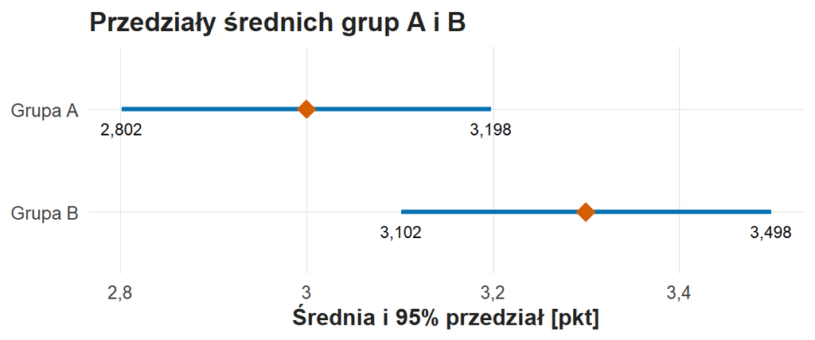

Przedziały średnich grup A i B. Oś pozioma: średnia w punktach. Grupa A: od 2,802 do 3,198, romb przy 3,0; grupa B: od 3,102 do 3,498, romb przy 3,3. Wspólny zakres obu przedziałów leży między 3,102 a 3,198.

```r
nakladanie <- pokaz_wykres(wykres_nakladania)
print(nakladanie)
```

Przedziały średnich nakładają się między 3,102 a 3,198, a przedział różnicy [0,021; 0,579] leży powyżej zera. Wykres przedstawia niepewność średnich; rozrzut osób przedstawia wykres pudełkowy. Właściwa estymanda ma własny przedział.

## Pary: pomiary powiązane

Sześć osób z wykładu W04 wykonało zadanie przed instruktażem i po nim. Parę tworzy identyfikator osoby; różnica po minus przed ma znak ujemny przy skróceniu czasu. Tabela „Sześć par pomiarów” podaje zmiany: −1, −2, −1, −3, −2 i −4 minuty.

```r
pomiary <- dane_par()
print(pomiary)
```

**Sześć par pomiarów**

| Osoba | Przed [min] | Po [min] | Zmiana po − przed [min] |
| --- | --- | --- | --- |
| a | 6 | 5 | -1 |
| b | 8 | 6 | -2 |
| c | 10 | 9 | -1 |
| d | 12 | 9 | -3 |
| e | 14 | 12 | -2 |
| f | 16 | 12 | -4 |

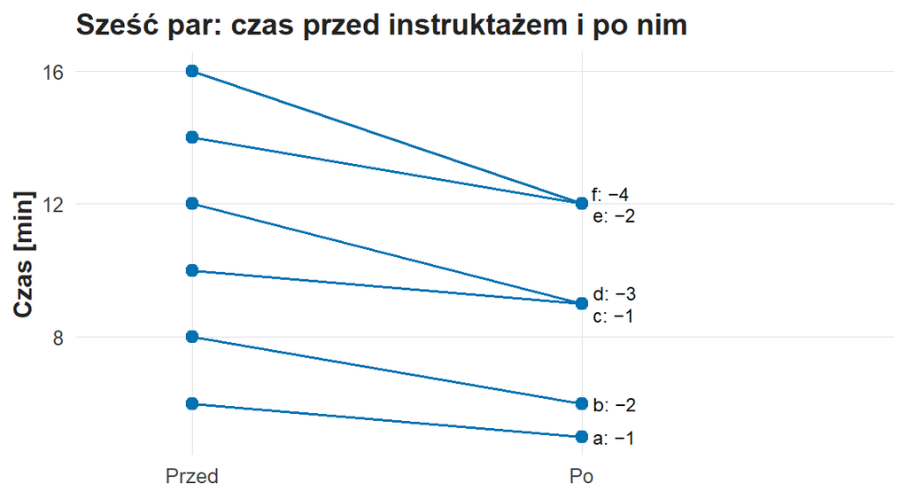

Sześć par: czas przed instruktażem i po nim. Oś pionowa: czas w minutach. Każdy odcinek łączy dwa pomiary jednej osoby; wszystkie sześć odcinków opada, o 1 do 4 minut, a etykiety przy pomiarze po podają osobę i zmianę.

```r
pary_wykres <- pokaz_wykres(wykres_par)
print(pary_wykres)
```

Test par jest testem jednej średniej zmian względem zera; N wynosi sześć par:

$$t=\frac{\bar d}{s_d/\sqrt{n_{\text{par}}}}=\frac{-2{,}17}{1{,}17/\sqrt6}=-4{,}54 .$$

Tabela „Test par: średnia zmian po − przed” podaje: średnia zmiana −2,167 minuty, SD zmian 1,169, SE 0,477, 95% CI od −3,394 do −0,940, t = −4,540, df = 5, p = 0,0062.

```r
zmiana <- test_par_do_raportu()
print(zmiana)
```

**Test par: średnia zmian po − przed**

| Miara | Wartość |
| --- | --- |
| N par | 6 |
| Średnia zmiana [min] | -2,167 |
| SD zmian [min] | 1,169 |
| SE średniej zmiany [min] | 0,477 |
| Dolna granica 95% CI | -3,394 |
| Górna granica 95% CI | -0,940 |
| t | -4,540 |
| df | 5 |
| p | 0,0062 |

Wariant „paired” wynika z projektu: te same osoby w dwóch pomiarach. Zmiana po instruktażu łączy działanie instruktażu z efektem powtórzenia zadania; rozdzielenie wymaga grupy kontrolnej.

## Mała grupa z dużym rozrzutem: znaczenie założenia Welcha

Pierwsza grupa liczy 10 osób i ma SD 10 minut, druga — 100 osób i SD 2 minuty. Wkłady do wariancji różnicy wynoszą $100/10=10$ i $4/100=0{,}04$, więc SE Welcha wynosi $\sqrt{10{,}04}=3{,}17$ minuty.

Wspólna wariancja łączy oba oszacowania: $(9\cdot100+99\cdot4)/108=12$, a SE w modelu równych wariancji wynosi $\sqrt{12\,(1/10+1/100)}=1{,}15$ minuty. Tabela „SE różnicy przy nierównych wariancjach” zestawia oba wyniki.

```r
se_modeli <- se_dwoch_modeli()
print(se_modeli)
```

**SE różnicy przy nierównych wariancjach**

| Model | SE różnicy [min] |
| --- | --- |
| Welch: osobne wariancje | 3,17 |
| Wspólna wariancja | 1,15 |

Przedział Welcha jest prawie trzykrotnie szerszy: w modelu wspólnej wariancji mała, zróżnicowana grupa zostaje „ściągnięta” przez dużą grupę o małym rozrzucie. Przykład przedstawia wpływ założenia o wariancjach na SE. Tasowanie etykiet łączy rozrzuty grup, więc przy nierównych wariancjach wymaga statystyki studentyzowanej.

## Próby interpretacyjne z omówieniem

### Próba A: znak niezgodny z opisem

Raport podaje „nowi minus doświadczeni = −0,44”, t = +3,82 i CI [0,21; 0,66]. Trzy liczby pochodzą z dwóch kierunków odejmowania: różnica 2−1 połączona z testem 1−2.

Poprawa ujednolica kierunek: dla kierunku nowi minus doświadczeni t i CI są ujemne. Opis przewagi doświadczonych wymaga przestawienia całego wyniku i nazwania nowej kolejności.

### Próba B: „g = 0,6, więc 60% osób korzysta”

g jest ilorazem różnicy średnich i SD. Poprawiony opis podaje naturalną różnicę oraz g jako standaryzowaną wielkość z nazwaną definicją. Pytanie o udział korzystających wymaga zmiennej kategorialnej i proporcji.

### Próba C: „p = 0,75 dowodzi takich samych czasów”

Przedział od −1,64 do 2,26 minuty opisuje zakres różnic zgodnych z danymi; część zakresu może mieć znaczenie praktyczne dla biblioteki.

Bliskość wyników wykazuje test równoważności z tolerancją ustaloną przed badaniem.

### Próba D: „istotna różnica oznacza dwie rozłączne grupy”

Wyniki osób mogą się silnie nakładać przy precyzyjnie oszacowanych średnich. Test dotyczy średnich; $\theta=0{,}333$ opisuje nakładanie rozkładów osób.

Decyzja o indywidualnym wsparciu opiera się na obserwowanych potrzebach osoby; statystyka grupowa opisuje wzorzec.

### Próba E: „obie metody dowodzą wpływu”

Welch i tasowanie korzystają z tych samych danych obserwacyjnych. Cecha nieobserwowana różniąca grupy wpływa na obie analizy jednakowo.

Poprawna interpretacja brzmi: w syntetycznej próbie odnotowano różnicę oceny związaną z grupą, przy określonych założeniach wnioskowania. Wniosek o przyczynie wymaga dodatkowego projektu.

## Laboratorium odpornego wniosku

### Jedna długa próba i dwa pytania

Nowi mają czasy 8, 9, 10, 11 i 42 minuty, a doświadczeni 7, 8, 9, 10 i 11. Średnie wynoszą 16 i 9, więc różnica średnich to 7 minut; mediany wynoszą 10 i 9, a różnica median — 1 minuta.

Średnia i mediana przy jednej długiej próbie

| Podsumowanie | Nowi | Doświadczeni | Nowi minus doświadczeni |
| --- | --- | --- | --- |
| N ważnych czasów | 5 | 5 | — |
| Średnia czasu [min] | 16 | 9 | 7 |
| Mediana czasu [min] | 10 | 9 | 1 |

Różnica 7 minut odpowiada na pytanie o średni nakład czasu, gdy 42 minuty są prawidłową obserwacją; długa próba ma znaczenie dla planowania wsparcia. Środek rozkładu opisuje mediana.

Po pominięciu 42 minut średnia nowych wynosi 9,5, a różnica 0,5 minuty. Decyzja o obserwacji wymaga informacji o pomiarze: działanie zegara, przerwa osoby, zgodność zadania z procedurą.

Korekta błędu ma podstawę w protokole i dzienniku. Analiza bez prawidłowej obserwacji jest jawnie oznaczonym sprawdzeniem wrażliwości, a wynik główny zawiera wszystkie prawidłowe obserwacje.

Mediana odpowiada na pytanie o środkowego użytkownika; raport zachowuje obie perspektywy.

### Zaokrąglenie i znak przedziału

Przedział różnicy [−0,004; 0,206] punktu po zaokrągleniu do dwóch miejsc ma dolną granicę 0,00. Dolna granica −0,004 oznacza przedział obejmujący zero.

Decyzja korzysta z wartości niezaokrąglonych, a prezentacja — z liczby cyfr zachowującej istotny szczegół. Trzy miejsca po przecinku wystarczają, razem z opisem „przedział obejmuje zero”.

Wartość p = 0,0496 po zaokrągleniu do dwóch miejsc wynosi 0,05 i pozostaje wynikiem obliczenia 0,0496; wniosek opiera się na efekcie i przedziale.

### Ta sama nazwa grupy, różne mechanizmy doboru

„Nowi użytkownicy” mogą oznaczać osoby na pierwszej wizycie, osoby korzystające krócej niż miesiąc albo osoby, które same tak się określiły. Trzy definicje wyznaczają trzy różne grupy; raport podaje regułę kwalifikacji.

Doświadczeni zaproszeni podczas zaawansowanego szkolenia i nowi zaproszeni przez otwarty formularz różnią się także mechanizmem rekrutacji. Różny mechanizm rekrutacji jest konkretnym ograniczeniem porównania.

Dalsza praca ujednolica zadanie, urządzenie i rekrutację oraz zbiera informacje o znajomości podobnych narzędzi. Projekt z przydziałem wersji pomocy niezależnym od doświadczenia odpowiada na pytanie o interwencję.

### Zdanie odporne na zmianę p

Opis zaczyna się od wielkości i kierunku różnicy, bez słów „istotny” i „nieistotny”; potem dochodzi przedział i ograniczenie, a na końcu statystyka i p. Opis, który przestaje być prawdziwy po zmianie ostatniej liczby, przypisuje za dużo znaczenia samemu testowi.

W S02 niższa średnia oceny nowych jest własnością danych. Precyzja i p opisują odczyt różnicy −0,438 w przyjętym modelu. Ograniczenia projektu i indeksu pozostają przy każdej wartości p.